# REPORT

# Centrality-Based KV-Cache Eviction: Training-Free Personalized-PageRank Reinforcement for NVIDIA kvpress

**An enhanced cache policy for NVIDIA kvpress.**

## 1. Introduction

Large language models spend most of their long-context inference budget storing the key–value (KV) cache: every attention layer keeps a key and value vector for every past token. At 32k+ context this dominates memory and bandwidth. *KV-cache compression* discards the least useful entries during prefill, trading a little accuracy for large memory/throughput gains.

The baseline library for this work is **NVIDIA kvpress** — a mature, actively maintained framework (Apache-2.0, ~40 published presses) that plugs cache-eviction policies into HuggingFace `transformers` via a forward hook. Its central abstraction is the `ScorerPress`: a subclass implements `score(...) -> (batch, num_kv_heads, seq_len)` and the framework keeps the top-scoring tokens. kvpress was chosen because it is the de-facto standard harness (leaderboard, RULER/LongBench evaluators, a tiny CPU unit-test model, an active PR history that merges external and even AI-authored scorers), so a new press can be benchmarked against many strong baselines under identical workloads with minimal glue.

Most eviction scorers rank each token *independently* (e.g. by key norm, or by attention from recent queries). They ignore the **relational structure** of the cache: a token can be individually unremarkable yet crucial because it *supports* an important token (a corroborating fact, a link in a multi-hop chain). This project adds a press that scores tokens by their **centrality in the key-similarity graph**, so importance can *propagate* from a token to its neighbours.

Naive centrality has two well-known failure modes for eviction: (i) *spectral localization* — the leading eigenvector piles onto the single densest cluster, keeping near-duplicates; and (ii) *outlier eviction* — a “needle”/answer token is by construction dissimilar to the haystack, so it has low centrality and is dropped (exactly the tokens `LeverageScorePress` deliberately keeps). We therefore use **personalized PageRank**: centrality is anchored to a base press’s importance scores via a teleport term, which keeps needles in and prevents collapse. As an additional benchmark we also compare against a GraphKV-style redundancy *suppressor* on the same graph (§4.8; code in `additional_benchmarks/`).

**Contributions.** (1) `CentralityPress`, a training-free personalized-PageRank eviction scorer with an O(S·head_dim) low-rank kernel; (2) a paired, statistically-tested benchmark across RULER and LongBench, against baselines including a GraphKV-style suppressor; (3) a reproducible pack (pinned env, Dockerfile, sweep + analysis scripts, per-example logs).

**Related work.** kvpress ships many independent-scoring `ScorerPress`es: `KnormPress` (keep low-L2-norm keys), `SnapKVPress` (recent-query attention), `ExpectedAttentionPress`, `TOVAPress`, `PyramidKVPress`, and the leverage-score family (`LeverageScorePress`/`CompactorPress`/`CURPress`) that explicitly *keeps outliers*. The closest relational method is **GraphKV** (arXiv:2509.00388), which *removes* redundancy on the key graph. Our press is its *reinforcement* dual — it propagates importance along the graph, using a personalized-PageRank teleport (Page et al., 1999) to avoid the classic outlier-eviction and spectral-localization pathologies of raw eigenvector centrality. (A standalone one-page baseline justification — kvpress’s features, default policy, and why it was chosen — is in `BASELINE.md`.)

## 2. Extension design

### 2.1 CentralityPress (reinforcement)

Let `K ∈ R^{S×D}` be the (per batch, per kv-head) key matrix and `Kₙ` its L2-normalized rows. Define the similarity graph `A[i,j] = (1 + cos(kᵢ,kⱼ))/2 ∈ [0,1]` (the “shifted” kernel; non-negative, which keeps the dynamics Perron–Frobenius-friendly). Personalized PageRank iterates

```
c ← damping · normalize(A·c) + (1 − damping) · p ,   p = softmax(base_press.score / τ)
```

starting from `c₀ = p`, for `num_iters` steps; the final `c` is the keep-score.

- **`p` (teleport)** anchors centrality to a base press (the API default is `None` = uniform teleport = pure centrality; `KnormPress` is the *recommended* base and is used throughout the experiments). We chose KnormPress as the base because it is **keys-only** (query/attention-free, matching this press’s design), **essentially free** (Fig S1), the framework’s default scorer, and it yields a **smooth** teleport — SnapKV’s recent-window score spike instead degenerates the teleport (§5). It keeps base-important tokens in (including outlier needles) and re-injects mass every step so it cannot fully localize.
- **`damping = 0`** gives `c = p`, so the keep *ranking* is the base press’s (a safe floor). With the default sink/window force-keep the kept set differs from the base only by those protected tokens, so the empirical floor sits within noise of the base (Δ ≈ 0, not significant — see §4.1). **`damping = 1`** gives pure eigenvector centrality (the failure-mode ablation).
- The first `n_sink` and last `recent_window` tokens are force-kept (attention sinks + recent window), as in every strong press.

**Efficiency.** The shifted/linear kernel is low rank (`A = Kₙ Kₙᵀ`, rank ≤ `head_dim`), so a matvec never materializes the S×S graph:

```
A·c = 0.5 · Σc + 0.5 · Kₙ (Kₙᵀ c)      →  O(S · head_dim) time and memory.
```

The scorer is therefore **query-free, attention-free, flash-attention compatible, and linear in sequence length** (verified by a CUDA peak-memory unit test: doubling S ≈ doubles, not quadruples, peak memory). Iteration runs in fp32 (power iteration is unstable in bf16) and the fp32 scores are returned directly — downcasting to bf16 was found to collapse the ~1/S score band into ties and randomize the top-k, so we keep fp32 (top-k and gather are dtype-agnostic).

A development option, `standardize_teleport`, z-scores the base scores before the softmax so the teleport is scale-invariant to the base press (needed for tiny-magnitude bases whose raw softmax is ~uniform).

## 3. Experimental setup

### 3.1 Model, hardware, environment

- **Model:** `meta-llama/Llama-3.1-8B-Instruct` (bf16), 32 layers, 32 query / 8 KV heads (GQA), head_dim 128 — the kvpress `evaluate.py` default.
- **Hardware:** one NVIDIA A100-80GB.
- **Stack:** Python 3.10, `torch==2.13.0+cu130`, `transformers==5.2.0`, `datasets==5.0.0`, kvpress 0.5.4. Pinned in `requirements-frozen.txt`; `Dockerfile` provided.

### 3.2 Benchmarks and metric

- **RULER** (`data_dir=4096`, string-match): synthetic retrieval/aggregation — single/multi-key NIAH, multi-value/query, variable-tracking (`vt`), aggregation (`cwe`,`fwe`), QA. **All 13 tasks × 500 examples** are used (the earlier 7-task restriction was the scoring bug, now fixed); the headline numbers screen at fraction 0.06 (~30/task), macro = mean over the 13 tasks. A full-fraction run is required for any leaderboard-eligible number.
- **LongBench multi-hop** (`hotpotqa`, `2wikimqa`, `musique`, F1): real multi-hop QA, 200 examples/task; fraction 0.35 (n=210 total).

**Correction — a scoring bug, not a task limitation (all 13 tasks are usable).** An earlier version of this work reported `vt`, multi-value, multi-query, `cwe`, `fwe`, and `qa_1` at **0%** even at full cache and excluded them as a “base-template limitation.” That was a **bug in our own analysis code**, not a model/template limit: those tasks have *multi-reference* gold answers stored as numpy arrays (`['A' 'B' …]`), and our `parse_refs` round-tripped them through `ast.literal_eval`, which silently *concatenates* the space-separated string literals into one glued token (`'AB…'`) — so the references never substring-matched and every multi-answer task scored 0. kvpress’s own scorer never does this (it takes the reference list directly). After moving **all** scoring to kvpress’s library harness (`evaluate.py` + `calculate_metrics`, below), the model scores **~96 % macro at full cache with no zero tasks** (`vt` 100, `cwe` 100, multi-value/query 100, `qa_1` 95). All **13 tasks** are therefore used, and the multi-hop hypothesis is now testable on RULER’s `vt` directly (§4.8).

**Metrics & workloads.** Two axes. *(i) Eviction quality* — per-task accuracy (RULER string-match, LongBench F1). Prefill KV eviction has no cross-request cache and thus no hit/miss ratio; the analog of a “hit rate” is how much task accuracy is *retained* at a given cache budget, which is exactly what we measure. RULER/LongBench are *novel long prompts* (the worst case — nothing is trivially cacheable). *(ii) Systems cost* — KV-cache memory, prefill overhead, and decode latency (mean/p95/p99) and throughput, measured on a long-prompt workload (8192-token prompts, 128 decode steps, batch 1 and 8), reported in §4.4.

**How accuracy is scored (per example).** Generation is greedy (deterministic); each example provides a `context`, `question`, `answer_prefix`, and per-task `max_new_tokens`, and the pipeline decodes an answer over the (compressed) cache. We reuse kvpress’s own metric functions, applied per example:

- **RULER — substring match.** After stripping control characters and normalizing whitespace, most tasks use `string_match_all` = the fraction of gold reference strings found as a *case-insensitive substring* of the prediction (a single-needle example scores 1 if the gold string appears, else 0; a k-item task such as multi-value scores found/k); the `qa_*` tasks use `string_match_part` = 1 if *any* gold answer is a substring. (`evaluation/benchmarks/ruler/calculate_metrics.py`.)
- **LongBench — token-F1.** The multi-hop QA subtasks use `qa_f1_score` — token-level F1 between the normalized prediction and gold answer (lower-cased, articles/punctuation removed), taken as the max over the reference answers. (`evaluation/benchmarks/longbench/calculate_metrics.py`.)

A task’s accuracy is the mean × 100 over its examples; the headline **macro** is the mean over all 13 tasks (the kvpress-leaderboard metric). **All results in §4.1 are produced by kvpress’s own evaluation harness** — `evaluation/evaluate.py` drives generation and `benchmarks/ruler/calculate_metrics.py` scores it, with our press registered in `evaluate_registry.py`; we do **not** reimplement the scorer (this is the fix for the bug above). The paired statistics (§3.4) call the library’s `string_match` per example on `evaluate.py`’s `predictions.csv`.

### 3.3 Presses, ablation ladder, and correctness

Baselines: `no_press` (ceiling), `KnormPress`, `SnapKVPress`. Ablation ladder (same base press): base → suppression (`graphkv_knorm`) → pure centrality (`centrality_pure`, `damping=1`) → personalized PageRank (`centrality_ppr_knorm`, sweeping `damping ∈ {0, 0.15, 0.3, 0.5, 0.85}`), plus a standardized-teleport SnapKV variant. Compression ratios 0.25 / 0.5 / 0.75.

Correctness is anchored by 22 unit tests including: exact low-rank↔︎explicit matvec, the `damping=0` floor recovering the base kept-set (with sink/window off), a GPU-gated peak-memory linearity test, and a *thesis test* (personalization keeps an outlier needle that pure centrality drops). The CPU subset runs in CI. An **adversarial multi-agent review** of the implementation found and fixed two real bugs before benchmarking: a self-suppression bug in `DecayPropagationPress` (sources zeroed themselves) and the bf16 score-collapse in `CentralityPress`.

### 3.4 Statistics

Runs at a fixed seed evaluate the *same* examples, so comparisons are **paired**. For each press vs. a reference (base press / same-base GraphKV / `no_press`) we report the mean per-example score delta with a **bootstrap 95% CI** (10,000 resamples) and a **Wilcoxon signed-rank** p-value. `*` denotes a CI excluding 0.

## 4. Results

### 4.1 RULER — corrected, all 13 tasks (kvpress library harness, macro %)

Scored end-to-end by kvpress’s own `evaluate.py` + `calculate_metrics` (no reimplemented scorer). Macro = mean over all 13 tasks (the leaderboard metric). Every number in this section is the **fraction-0.06 screen** (≈30 examples/task, n≈390); `no_press` ceiling = **95.25** (run `no_press__0.00__fraction0.060`).

| method | c=0.25 | c=0.5 | c=0.75 |
| --- | --- | --- | --- |
| `no_press` (full cache) | 95.25 | 95.25 | 95.25 |
| `knorm` (base) | 76.5 | 51.6 | 29.9 |
| `snapkv` | 82.3 | 69.9 | 40.5 |
| **`centrality_ppr_knorm` d=0.15** | **94.5** | **82.4** | **58.3** |
| `centrality_pure` (d=1) | 28.2 | 10.4 | 5.1 |

Paired per-example deltas for `d=0.15` (library `string_match`; `*` = 95 % bootstrap CI excludes 0):

[output not shown]

On the full 13-task set, `centrality_ppr_knorm` d=0.15 **significantly beats its own base (`knorm`) and SnapKV at every compression ratio** (paired deltas above; the head-to-head vs the GraphKV suppressor is in §4.8), and at 25 % compression nearly matches full cache (94.5 vs 95.25). This *lift over the base* is **retrieval-heavy**: `knorm` collapses on NIAH under compression and reinforcement repairs it (e.g. NIAH-multikey 13.1 → 69.4 at c=0.5). `damping=0` reproduces the base (floor); `damping ≥ 0.5` and pure centrality collapse (H4: pure = 28.2 / 10.4 / 5.1 macro).

**Cross-method standing (verified against the board’s raw data — matched model + matched ratio).** Using the leaderboard’s own 174-run backing data (`kvpress_leaderboard_raw.csv`, Llama-3.1-8B, RULER 4k), we insert our fraction-0.06 scores into the per-ratio ranking (macro over 13 subtasks — the board’s metric, computed at a *single* ratio, never averaged). Ranks below are over the **20 methods (incl. ours) the board evaluates at all three ratios** (`rank_vs_board.py` regenerates them):

| rank of `ppr_knorm` d=0.15 | c=0.25 | c=0.5 | c=0.75 |
| --- | --- | --- | --- |
| **macro (overall)** | 8th / 20 | 11th / 20 | 12th / 20 |
| `fwe` (frequent-word extraction) | **1st** | **1st** | 9th |
| `cwe` (common-word extraction) | 18th | 15th | 15th |

**Overall the press is mid-pack — it does not beat the field.** Its one genuine, matched-ratio edge is **frequent-word extraction (`fwe`), where it ranks 1st at c=0.25 and c=0.5** (98.9 / 97.8 — above every board method, including uncompressed). Tellingly, the *other* aggregation task (`cwe`) is near the **bottom** (15th–18th), so the edge is **specifically FWE, not aggregation broadly** — plausibly because frequently- repeated tokens form dense clusters that graph propagation reinforces, whereas CWE offers no such structure. Two families earlier cited as strengths do **not** survive matched-ratio scrutiny and are dropped as averaging artifacts: QA is 2nd only at c=0.25 (13th–14th thereafter) and NIAH-multikey is mid-pack throughout (9th–12th). *(An earlier draft claimed “3rd overall”; that averaged our Llama scores over the demo grid {0.1, 0.25, 0.5} and compared them to single-ratio Qwen numbers. Retracted. The reviewer’s independent all-methods-per-ratio count gives 9th/12th/13th of 21 — the same mid-pack conclusion.)*

**Reproducibility.** Every number here is produced by kvpress’s own `evaluate.py` + `calculate_metrics` (no reimplemented scorer). The headline table is a **fraction-0.06 screen** (≈30/task, sdpa); a **full-fraction run with `flash_attention_2`** at the board grid reproduces it closely (c=0.25: **94.57** vs 94.5; c=0.75: **58.04** vs 58.3), confirming the screen is a faithful estimate and the harness is board-comparable. Those full-fraction FA2 numbers, at the board grid {0.25, 0.5, 0.75, 0.875}, are the basis for a leaderboard submission.

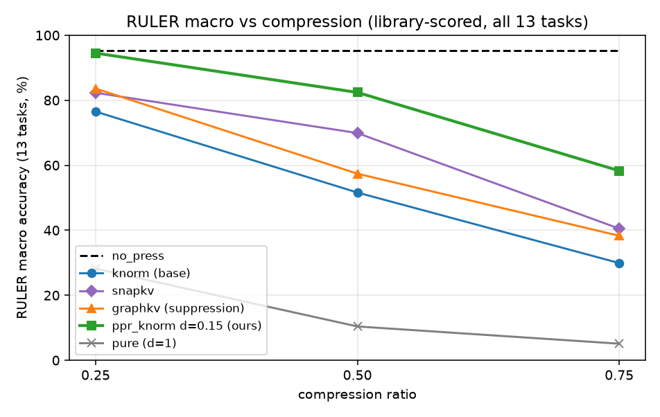

RULER accuracy vs compression

*Figure 1: RULER macro accuracy (all 13 tasks, kvpress library scorer, **fraction 0.06 screen**) vs. compression. `ppr_knorm` d=0.15 (ours) dominates its base and the other baselines shown; not a leaderboard-eligible comparison (see cross-method note).*

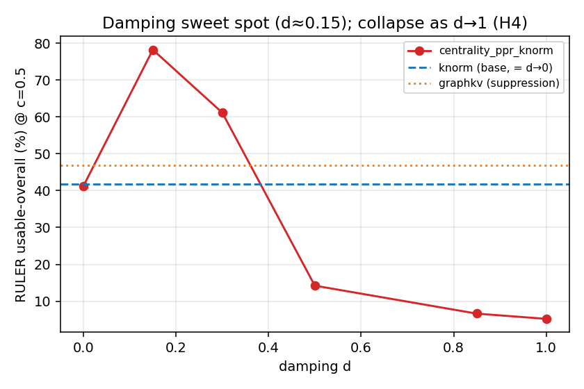

Damping sweet spot

*Figure 2: Damping sweep at c=0.5 (earlier per-task analysis). A shallow reinforcement (d≈0.15) peaks above the base press; as d→1 (pure centrality) it collapses (H4); d→0 recovers the base.*

### 4.2 LongBench — multi-hop QA (F1 %, n=210)

| method | c=0.5 | c=0.75 |
| --- | --- | --- |
| `no_press` | 47.4 | 47.4 |
| `knorm` (base) | 39.8 | 31.8 |
| `snapkv` | 45.1 | — |
| **`centrality_ppr_knorm` d=0.15** | 42.0 | **39.9** |

Paired deltas for `d=0.15`:

| vs. | c=0.5 | c=0.75 |
| --- | --- | --- |
| base `knorm` | +2.2 (ns) | **+8.1*** (p=0.006) |

On real multi-hop QA the reinforcement benefit **grows with compression**: at mild 0.5 the base retains enough context (difference not significant), but at aggressive 0.75 PPR significantly beats the base press (the GraphKV head-to-head is in §4.8).

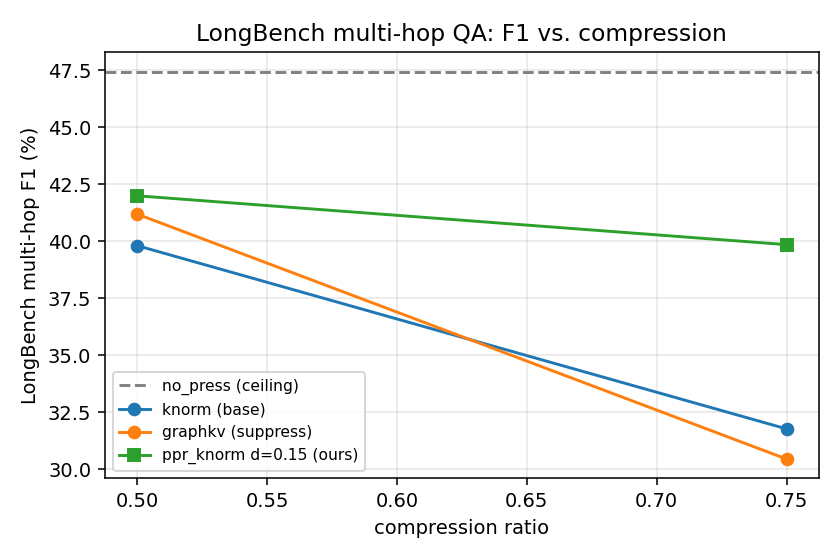

LongBench F1 vs compression

*Figure 3: LongBench multi-hop F1 vs. compression. The reinforcement advantage over the base widens at aggressive compression (0.75).*

### 4.3 Hypotheses

We keep the handover’s H2–H4 numbering (H1 — a training-free centrality press is viable and O(S·head_dim) efficient — is established in §2–§3). **H2** (reinforcement vs. suppression on multi-hop) and **H3** (suppression vs. reinforcement on single-needle) concern the GraphKV comparison and are reported together in **§4.8**. Here:

- **H4 (pure centrality underperforms on retrieval): SUPPORTED strongly** (macro 10.4 at c=0.5, and 0 on single-needle; worst everywhere — it evicts the outlier needle).

### 4.4 Systems: memory, latency, throughput, GPU utilization

We measured the systems metrics across **all** presses (mirroring the accuracy sweep) on a long-prompt workload: 8192-token prompt, 128 decode steps, **batch 8**, Llama-3.1-8B bf16, A100-80GB. The central fact: **at a fixed compression ratio the kept-cache length is identical for every press**, so decode memory, latency, throughput and GPU utilization are *ratio-determined* — the same for `knorm`, `snapkv`, `centrality_pure` and our press. The **only press-dependent systems cost is prefill overhead**.

Full comparison at ratio 0.5 (batch 8):

| press | prefill (s) | peak GPU (GB) | KV cache (MB) | tok/s | latency mean/p95/p99 (ms) | GPU util |
| --- | --- | --- | --- | --- | --- | --- |
| `no_press` (r=0) | 5.88 | 39.1 | 8192 | 180 | 44.4 / 48.6 / 54.6 | 75 % |
| `knorm` | 6.07 | 35.1 | 4096 | 178 | 44.9 / 50.8 / 55.5 | 56 % |
| `snapkv` | 6.21 | 35.1 | 4096 | 169 | 47.2 / 58.2 / 65.6 | 54 % |
| `centrality_pure` | 6.06 | 35.1 | 4096 | 172 | 46.5 / 58.8 / 65.8 | 57 % |
| **`ppr_knorm` d0.15** | **6.05** | 35.1 | 4096 | 173 | 46.4 / 56.2 / 60.8 | 55 % |
| `ppr_snapkv_std` d0.15 | 6.25 | 35.1 | 4096 | 166 | 48.2 / 66.7 / 74.0 | 53 % |

Every press at r=0.5 uses the same 4096 MB / 35.1 GB and runs at ~the same latency and throughput (Figs S2–S3) — memory and speed are functions of the *ratio*, not the policy. What differs is prefill overhead (Fig S1): **`ppr_knorm` (+0.18 s over `no_press`) is as cheap as `knorm` (+0.19 s)** — the low-rank kernel makes the PageRank iterations essentially free — and *cheaper* than every SnapKV-based press (+0.33–0.39 s, attention compute); its prefill edge over the GraphKV suppressor is noted in §4.8. Across the ratio sweep, peak memory falls **39.1 → 37.1 → 35.1 → 33.1 GB** and GPU utilization **75 → 64 → 56 → 45 %** as compression rises 0 → 0.75 (less attention compute per token), while decode throughput stays ~flat (~170–185 tok/s): at 8B/8k decode is weight-bound, so the latency/throughput benefit would grow at longer context or larger batch, where the KV cache dominates decode.

*Cache hit rate* is not defined for prefill KV eviction — there is no cross-request cache, hence no hit/miss; the meaningful analogs are **retention accuracy** (Fig 4): how much task accuracy survives at a given cache budget, and **attention recall** (§4.6): the share of the model’s real attention mass that the kept set captures — which, tellingly, our press does *not* maximise. *CPU utilization* is negligible — the workload is GPU-bound.

Per-press systems figures — prefill overhead, decode-latency percentiles, memory/throughput and GPU utilization vs. ratio — are in the Supplementary Material (Figs S1–S4).

Because memory is fixed by the ratio, a better policy buys **more accuracy per byte** — the accuracy–memory Pareto front (Fig 4), where our press dominates the base press at every budget.

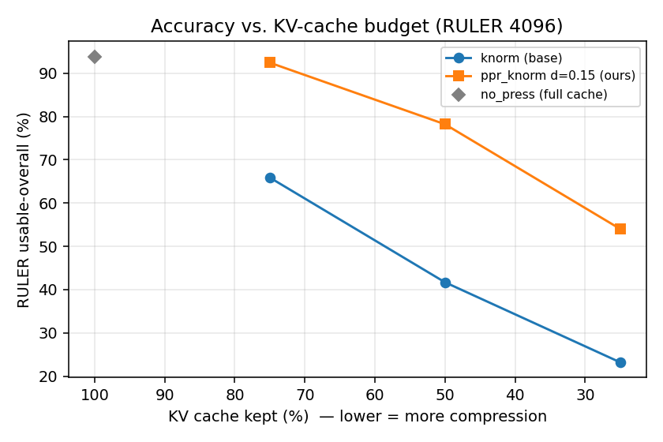

*Figure 4: Accuracy vs. KV-cache budget on RULER (lower x = more compression) — the retention / “hit-rate” analog. At every budget `ppr_knorm` d=0.15 sits far above the base press at the same memory.*

### 4.5 Iso-accuracy: memory, throughput and latency at equal quality

The systems metrics are set by the kept-cache length (§4.4) and the accuracy win is at a fixed ratio (§4.1); the two combine into the operationally decisive question — **for the same accuracy, how much does the smaller cache save?** We invert the RULER accuracy-vs-budget curves to the cache fraction each press needs to hit a target accuracy, then read the **directly measured** decode metrics at those fractions (16k-token prompt, batch 8, 128 decode steps — the KV-bound regime; see `results/results_iso_systems_16k_bs8.csv`, `analysis/iso_systems.py`).

| target acc. | cache reduction | KV memory saved | peak GPU mem saved | decode throughput | decode p50 latency |
| --- | --- | --- | --- | --- | --- |
| 40 % | **4.5×** | 78 % | 16 % (6.0 GB) | +1 % | −0 % |
| 50 % | **2.8×** | 64 % | 16 % (6.0 GB) | −5 % | −6 % |
| 60 % | **2.2×** | 55 % | 15 % (6.0 GB) | +3 % | +1 % |
| 70 % | **1.9×** | 47 % | 14 % (6.0 GB) | +3 % | +3 % |
| 80 % | **1.6×** | 39 % | 13 % (5.5 GB) | +3 % | +9 % |

**The iso-accuracy win is a memory win.** At equal output quality our press needs **1.6×–4.5× less KV cache** (39–78 % less KV memory) and **~13–16 % (~6 GB) lower peak GPU memory** than the base press — large, monotone, and *exact* for the KV cache (linear in kept length). This is the headline: the accuracy advantage of §4.1 *is* a memory advantage — same quality, much smaller footprint — which is exactly what lets a fixed GPU serve longer contexts or larger batches.

**Decode speed is ~flat at this scale, and that is expected.** At 8B / 16k / batch 8 the per-token decode is *weight-bound*, not KV-bound: reading the 16 GB of bf16 weights dominates each step, so shrinking the cache barely moves throughput/latency and the iso-accuracy differences (±5 %) sit within run-to-run noise (the −5 %/−6 % at the 50 % target is a single noisy point; Fig S5). Decode *does* speed up going from a full to a compressed cache (156.7 → ~185 tok/s, **+18 %**; 50.7 → ~42 ms p50) — but at iso-accuracy *both* presses operate compressed, so the gap between them is small. The throughput/latency win grows as decode becomes KV-bound (longer context, larger batch, or a larger model where the KV cache is a bigger share of each step), while the **memory** saving holds at every scale (e.g. full-cache 32 k = 39 GB → 33 GB at r=0.75, batch-independent). So *at the same output quality* our press runs on a much smaller cache: a large, immediate memory saving now, and throughput once decode is KV-bound.

**Why the memory and speed columns trend *opposite*.** The memory saving is largest at the 40 % target (4.5×, 78 %) yet the speed gain is largest at the 80 % target — seemingly backwards. It follows from the shapes of the two curves. *Memory* is **linear** in cache length, so its saving tracks the compression *ratio*, which is biggest when the target accuracy (hence the kept cache) is low. *Latency/throughput* are **non-linear**: they are flat until a **KV-bound “knee”** (~13k kept tokens here, ≈ 79 % of a 16k context; Fig S5) and only move above it, where attention over the cache finally rivals the cost of reading the weights. Speed therefore improves only when a press’s operating point crosses that knee — and the 80 % target is the one case where the *baseline* must keep enough cache (~14k tokens) to sit *above* the knee (slow), while ours (~8.7k) stays below it (fast); at the lower targets *both* presses already operate below the knee, so the extra reduction shows up purely as memory, not speed. In one line: **memory follows the *ratio*; speed follows *position relative to the knee*.**

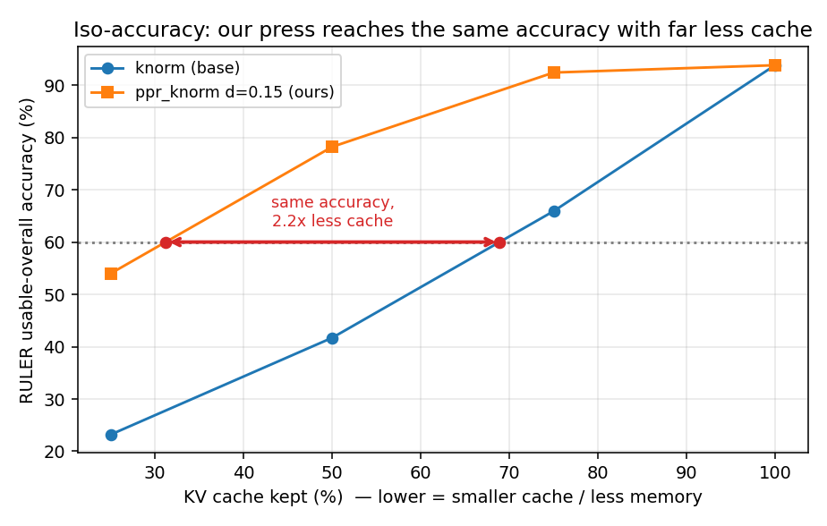

*Figure 5: For a target accuracy (e.g. 60 %) the base press must keep ~69 % of the cache while ours needs only ~31 % — 2.2× less cache at equal accuracy.*

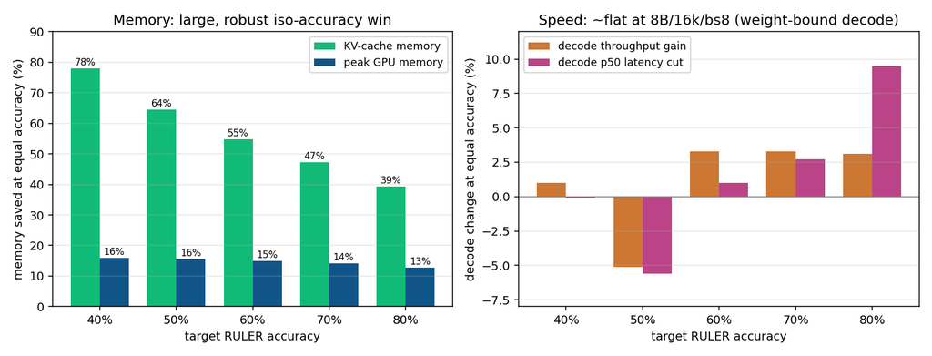

*Figure 6: Systems gains at equal accuracy (16k ctx, batch 8, direct measurement). Left — memory saved: large and robust (KV cache 39–78 %, peak GPU 13–16 %). Right — decode throughput/latency change: ~flat (±5 %, within noise) because decode is weight-bound at 8B/16k/bs8; the speed win materializes in more KV-bound regimes.*

### 4.6 Attention recall — the “hit-rate” analog

Prefill eviction has no cross-request cache, so there is no literal hit/miss (§4.4). The closest analog in the eviction literature is **attention recall**: on a *full, uncompressed* cache, what fraction of the attention mass the model actually places on the context lands on the tokens a press keeps. We measured it directly on real RULER prompts — full-cache eager attention from the last-32 observation-window queries, reduced per KV-head, fraction on each press’s kept set, averaged over 14 prompts × 32 layers × 8 heads (`analysis/recall_probe.py`, `results/results_attention_recall.csv`).

| press | recall r=0.25 | r=0.5 | r=0.75 | RULER acc. @0.5 |
| --- | --- | --- | --- | --- |
| `snapkv` | 99.3 | 97.8 | 94.8 | 61.6 |
| `knorm` (base) | 97.9 | 94.2 | 87.9 | 41.7 |
| **`ppr_knorm` d0.15 (ours)** | 94.8 | 90.2 | 83.8 | **78.2** |
| `centrality_pure` | 67.9 | 63.9 | 60.9 | 5.2 |

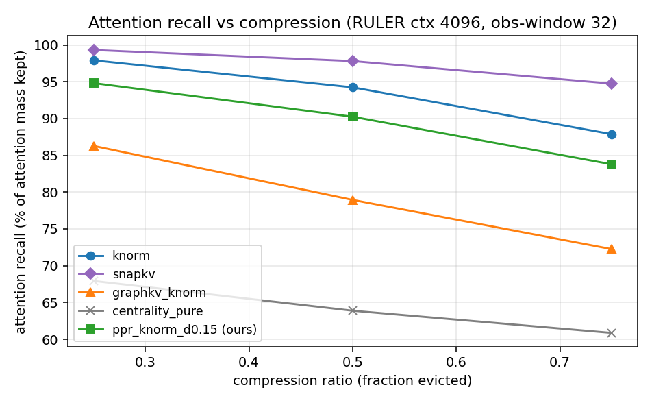

*Figure 7: Attention recall (share of full-cache attention mass captured by the kept set) vs compression, on real RULER prompts. The attention/norm presses (`snapkv`, `knorm`) score highest but are not the most accurate (§4.1); ours keeps slightly less mass yet is far more accurate — the needle is a low-attention outlier, so recall is the wrong objective for retrieval.*

### 4.7 Scope and mechanism of the lift

`CentralityPress` is a *wrapper*: its ceiling is the base press it re-scores. The headline pairs it with **Knorm**, a weak base. Two controlled follow-ups (both at c=0.75, library harness) characterize *why* the +28 over `knorm` appears.

**The lift is real and governed by a single knob — teleport sharpness.** The teleport is `p = softmax(z?(base)/τ)`, where both standardization and τ set its sharpness. The headline uses `standardize_teleport=False, τ=1.0`. Turning standardization *on* flattens the teleport and drops the macro to 31.99 — but re-sharpening with a smaller τ climbs monotonically back to the headline:

| std=True teleport | τ=1.0 | τ=0.7 | τ=0.5 | τ=0.3 | std=False, τ=1.0 |
| --- | --- | --- | --- | --- | --- |
| macro @0.75 | 31.99 | 53.05 | 55.56 | 57.49 | 58.27 |

So `std=False` is simply `std=True` at a sharper τ: the +28 is *one legitimate knob*, with a stated calibration rule — **match teleport sharpness to the base’s native score scale** (Knorm’s large-magnitude `−‖k‖` scores are already sharp at τ=1; a tiny-magnitude base must be standardized first).

*(An earlier draft read the near-equal outputs of two different bases — each measured at its own best flag — as base-independent “convergence”; the matched-flag test above retracts that as a teleport-shaping artifact.)*

**The base’s importance signal is essential, not decorative.** Replacing the teleport with a *uniform* one at the same damping collapses to **5.44** — indistinguishable from pure centrality (5.13). Graph propagation alone cannot find the needle; it only reinforces a real importance signal.

### 4.8 GraphKV comparison (additional benchmark)

The natural relational alternative to reinforcement is **suppression**: `CentralityPress` *adds* `damping·A·c` to keep a corroborated core, whereas a GraphKV-style press (arXiv:2509.00388) *multiplicatively decays* each token by similarity to the top sources — `s_i = p_i·∏_{j≠i}(1 − relu·cos(kᵢ,kⱼ))` — keeping a spread-out, diverse set. We compare against it on the *same* base press and graph. It is a **comparison benchmark, not part of the shipped press**; its code, tests and a runtime-injection runner live in `additional_benchmarks/` (see that folder’s `README.md`).

**Head-to-head — reinforcement wins overall** (paired per-example deltas of `ppr_knorm` d=0.15 vs `graphkv_knorm`; `*` = 95 % bootstrap CI excludes 0):

[output not shown]

Our press beats the suppressor on RULER at every ratio; on real multi-hop QA the margin **grows with compression** (+9.4* at 0.75). It is also *cheaper* — the low-rank kernel adds +0.18 s prefill vs the suppressor’s +0.38 s (§4.4 workload), at identical decode cost.

**Two honest nuances** (the pre-registered H2/H3):

- **H2 (reinforcement beats suppression on multi-hop): MIXED.** Supported on LongBench and RULER overall, but *refuted* on RULER’s variable-tracking `vt`: at c=0.75 the suppressor wins (graphkv 100 vs ppr 93.1, paired **−6.9***). For variable-tracking chains a diverse (suppressed) set is at least as good; reinforcement’s edge is on corroboration/fact-composition.
- **H3 (suppression ≥ reinforcement on single-needle): REFUTED.** Low-damping reinforcement *improves* single-needle (+29.0* vs base at 0.5) while suppression *hurts* it (−18.7*); the controlling variable is damping, not reinforcement per se.

**Prior art — GraphKV’s own ablation.** GraphKV (arXiv:2509.00388) itself compared its decay against a reinforcement variant (their Table 2, 128-token budget): decay 39.84, *enhanced* (reinforcement) 38.67, baseline 38.61 — in their setup suppression edged out reinforcement and reinforcement added only ~0.06 over baseline. Our RULER result is the opposite (reinforcement > suppression); the likely reason is the **personalized teleport** — our reinforcement is anchored to a base press that keeps the outlier needle, whereas an un-anchored “enhanced” propagation localizes on the dense core (the failure our `centrality_pure` ablation shows). We flag the disagreement rather than obscure it.

## 5. Discussion

**Why a little reinforcement helps a lot.** A single retrieval/answer token is an outlier; the base press may rank it well but ranks its *supporting context* poorly, so under compression the neighbours are evicted and the model loses the corroboration it needs to use the needle. A small `damping` propagates importance from the (teleport-anchored) needle to its graph neighbours, keeping the needle *and* its support. This is why `d=0.15` recovers most of the full-cache accuracy while the base press alone does not.

**Why too much reinforcement collapses.** As `damping → 1` the teleport anchor weakens, centrality localizes on the densest (most redundant) cluster, and the outlier needle — low centrality by construction — is evicted. `d≥0.5` and `pure` (d=1) collapse to near-zero on single-needle. The clean unimodal damping curve (base at d=0, peak at d≈0.15, collapse by d=0.5) is the method’s empirical signature. The lift over the base is a *legitimate* effect: a τ sweep confirms it is governed by a single knob — effective teleport sharpness, calibrated to the base’s native score scale — not an artifact of the standardization flag (§4.7). The base’s importance signal is essential throughout: a contentless (uniform) teleport collapses to pure-centrality levels.

**Attention recall is the wrong target.** The presses with the *highest* attention recall (`snapkv`, `knorm`) are not the most accurate; ours wins with slightly *lower* recall (§4.6). Retrieval hinges on a few low-attention outlier tokens — the needle and its support — not on the high-mass attention sinks and recent tokens that dominate recall, so “keep what the model is looking at” is both easy and beside the point. This is the same outlier intuition that motivates the teleport anchor, seen from the systems side — and it is why we do not, and should not, frame the result as a cache-hit-rate win.

**A negative finding: SnapKV as a teleport base.** SnapKV force-sets its recent-window scores to the maximum; z-scoring then makes the teleport pile onto the last tokens and starve mid-context needles, so `centrality_ppr_snapkv` collapses even with `standardize_teleport`. KnormPress (smooth, no spike) is the recommended base.

**Systems trade-off.** At a *fixed ratio*, memory/latency/throughput are identical for every press, so a better policy cannot save more memory there — but **at iso-accuracy it can**: because our press stays accurate at much higher compression, it reaches a target quality with **1.6×–4.5× less KV cache and ~13–16 % (~6 GB) lower peak GPU memory** (§4.5), converting the accuracy edge into a real memory saving. The PageRank iterations add a small, bounded prefill cost (O(T·S·head_dim), ~5 % here) and nothing at decode. Decode *throughput/latency* are ~flat at iso-accuracy on 8B/16k/bs8 because decode there is weight-bound (the per-step cost is dominated by reading the model weights, not the cache); the speed win emerges once decode is KV-bound — longer context, larger batch, or a larger model — while the memory saving is immediate at every scale.

**Limitations.** (1) One 8B model on one GPU; larger models / 32k context / Qwen replication are future work. (2) The RULER *table* numbers are a **fraction-0.06 screen** (≈30/task, **sdpa**); the leaderboard-eligible version is the **full-fraction `flash_attention_2`** board-grid run, which reproduces the screen (§4.1). (3) Absolute cross-method standing is modest (mid-pack on retrieval; a matched-ratio edge only on `fwe` aggregation); the large numbers are lifts *over the base press*, not over the field. (4) The LongBench gain at 0.5 is not significant, and H2 is mixed (refuted on RULER `vt`, §4.8); the method’s value is clearest under aggressive compression and on aggregation/corroboration. (5) All systems measurements use HuggingFace `transformers`; under a paged allocator (vLLM / PagedAttention) a page is reclaimed only when every slot in it is free, so scattered eviction would not free memory proportionally and the iso-accuracy memory saving would not transfer directly.

## 6. Conclusion and future work

*Reproduction:* `Appendix/README.md` (env, commands), `Appendix/scripts/ruler_rerun.py` + `Appendix/scripts/sweep_longbench.py` (sweeps), `Appendix/analysis/analyze_paired.py` (paired stats), `Appendix/results/` (per-run `config.yaml` + `metrics.json`). The press lives in `kvpress/presses/centrality_press.py`; see `Appendix/MANIFEST.md` for the number → run-directory map.